# TeoNAM DTA (days to anthesis) — MLM (Family + K) GWAS with candidate genes + coverage sweep [118K panel]

The OLS model (Family + marker) plus a K random effect, on the authentic 118,838-SNP panel, and the five-caller coverage-degradation sweep under MLM

Author

Fausto Rodríguez-Zapata

Published

July 8, 2026

**What this is.** The MLM counterpart of `teonam-qtl-recovery-118k`: the same figures — JLM lollipop (Fig 4A), the authentic 118K GWAS Manhattan, the coverage-degradation composite, caller noisiness — but the GWAS model is a **mixed model** instead of OLS. The fixed structure is the **5-family factor** (the OLS/JLM structure), so this is literally “**OLS (`Family + marker`) + a K random effect**” and the OLS↔︎MLM contrast is the K term alone. In TeoNAM the structure *is* the five families, so this matches Chen’s Q = 5 PCs (Q ≈ Family; interchangeable — `scripts/teonam_mlm_family_118k.R`). Chen’s **exact** Fig-4C (TASSEL Q = 5 PCs + Centered_IBS K) and the QQ/λ_GC head-to-head are the sibling notebook `teonam-stam-mlm-gwas-118k`.

**ImportantKinship: full-data vs per-coverage**

- **Panels B & C** (authentic per-SNP and FSFHap ancestry-imputed) use K (VanRaden) estimated on the *full* panel — the single-experiment correction (R-EMMAX, `scripts/teonam_mlm_family_118k.R`, `teonam_mlm_fsfhap_118k.R`).
- **The coverage sweeps** keep the **Family** fixed term (known a priori, coverage- independent) but cannot use a full-panel K — at low coverage you only have shallow reads. So each coverage λ gets its **honest K homologue**: K (VanRaden) from the **GL dosage of the downsampled reads, *before* ancestry calling** (`scripts/teonam_mlm_null_bycov_118k.R`). K is caller-independent (one null per coverage), so only the *tested* recovered genotypes differ per caller. Per-marker test: `scripts/emmax_qk.R` (R-EMMAX, P3D, joint 2-df).

The central MLM result is a **confound, not a bug**: for flowering time K = teosinte-ancestry relatedness is nearly collinear with the QTL (teosinte is late-flowering, so a RIL is late *because* it carries teosinte alleles at photoperiod loci like *ZmCCT10*/*ZCN8*), so the mixed model **absorbs the very signal it is meant to protect** — worst where K is best estimated (high coverage / full panel). This is why Chen used **JLM** (Fig 4A), not MLM, for the DTA QTL, and why the degradation sweep runs *backwards* under MLM.

```r
library(here)
library(data.table)
library(ggplot2)
library(fastman)
library(ggrepel)
library(ggtext)
library(scales)
library(cowplot)
```

```r
source(here("scripts/teonam_notebook_plots.R")) # shared plot helpers: get_transformer, plot_manhattan/lollipop/sweep_line, lambda_gc, read_mlm_tassel, LOD

# Panel B = MLM (Family + K) on the authentic per-SNP panel (R-EMMAX; scripts/
# teonam_mlm_family_118k.R). Family (not 5 PCs) so B and C share the OLS structure and
# the OLS<->MLM contrast is the K term alone. The faithful TASSEL Q+K Fig-4C (Chen's
# exact model) is the sibling notebook teonam-stam-mlm-gwas-118k.html; read_mlm_tassel()
# below still parses it if needed.
mlm <- fread(here("data/teonam/dta_gwas_mlm_family_118k.csv"))
```

## Candidate genes: closest marker vs most-significant marker (v5)

For each DTA candidate gene (B73 v5), the **closest** marker (smallest bp distance to the gene body) vs the **window-max** marker (highest −log₁₀P within ±500 kb) in the authentic 118K **MLM (Family+K)** scan. As under OLS they are not the same marker: the closest marker sits on the gene but carries little signal; the local peak is a nearby but distinct marker.

```r
sc <- copy(mlm)[is.finite(P) & P > 0][, logP := -log10(P)]
# 11 DTA (flowering) candidates, v5-verified (data/teonam/dta_candidate_genes.tsv):
# display symbol + gene_id + coords + Chen 2019 QTL. Read directly (display names
# zcn12/zmcct9/zmcct10 differ from the file's canonical pebp12/cct2/cct1).
gg <- fread(here("data/teonam/dta_candidate_genes.tsv"))
gg[, chr := as.integer(chr)][, qtl := ifelse(qtl_chen2019 == "" | is.na(qtl_chen2019), paste0("DTA(chr", chr, ")"), qtl_chen2019)]
WIN <- 5e5
ctab <- rbindlist(lapply(seq_len(nrow(gg)), function(i) {
  ch <- gg$chr[i]
  s <- gg$start[i]
  e <- gg$end[i]
  m <- sc[CHR == ch]
  d <- pmax(0L, pmax(s - m$BP, m$BP - e))
  kc <- which.min(d)
  w <- m[BP >= s - WIN & BP <= e + WIN]
  kw <- which.max(w$logP)
  data.table(
    gene = gg$symbol[i], QTL = gg$qtl[i], chr = ch, `gene start (v5)` = s,
    `closest Δstart (bp)` = m$BP[kc] - s, `closest -log10P` = round(m$logP[kc], 2),
    `window-max Δstart (bp)` = w$BP[kw] - s, `window-max -log10P` = round(w$logP[kw], 2)
  )
}))
setorder(ctab, chr, `gene start (v5)`)
knitr::kable(ctab, format.args = list(big.mark = ","), caption = paste(
  "DTA candidate genes (B73 v5): CLOSEST marker vs highest -log10P marker within +/-500 kb",
  "(authentic 118K MLM Family+K scan). Δstart = marker bp - gene start (v5), signed."
))
```

DTA candidate genes (B73 v5): CLOSEST marker vs highest -log10P marker within +/-500 kb (authentic 118K MLM Family+K scan). Δstart = marker bp - gene start (v5), signed.

| gene | QTL | chr | gene start (v5) | closest Δstart (bp) | closest -log10P | window-max Δstart (bp) | window-max -log10P |
| --- | --- | --- | --- | --- | --- | --- | --- |
| zagl1 | DTA(chr1) | 1 | 283,849,414 | 310 | 1.98 | 256,113 | 2.73 |
| zmads69 | DTA(chr3) | 3 | 161,172,047 | 278 | 2.81 | 498 | 3.30 |
| zcn12 | DTA3.2 | 3 | 202,794,887 | -474 | 1.17 | -95,536 | 1.68 |
| tu1 | DTA4.1 | 4 | 183,877,026 | 446 | 0.59 | -309,305 | 2.78 |
| zmm31 | DTA5.1 | 5 | 7,374,462 | 345 | 0.94 | -332,215 | 1.77 |
| si1 | DTA6.1 | 6 | 94,458,037 | 800 | 0.16 | -396,046 | 1.96 |
| zag1 | DTA6.2 | 6 | 142,692,209 | 66,495 | 0.66 | -258,481 | 3.87 |
| dlf1 | DTA7.2 | 7 | 184,528,042 | 16,180 | 0.13 | -353,636 | 2.35 |
| zcn8 | DTA(chr8) | 8 | 126,678,681 | 4,819 | 0.84 | 11,113 | 6.80 |
| zmcct9 | DTA(chr9) | 9 | 120,960,326 | 134,868 | 4.42 | 198,308 | 5.00 |
| zmcct10 | DTA(chr10) | 10 | 96,175,873 | -40,959 | 10.89 | 369,774 | 19.28 |

## JLM QTL genomic distribution (Fig 4A)

The DTA QTL from JLM (TASSEL stepwise, nested-in-family), candidate genes bold-italic above their nearest QTL. **This arm is model-independent** — JLM, not MLM — so the lollipop is identical to the OLS notebook; it is Chen’s *primary* DTA analysis and the correct home for these flowering-time QTL (see the MLM confound below).

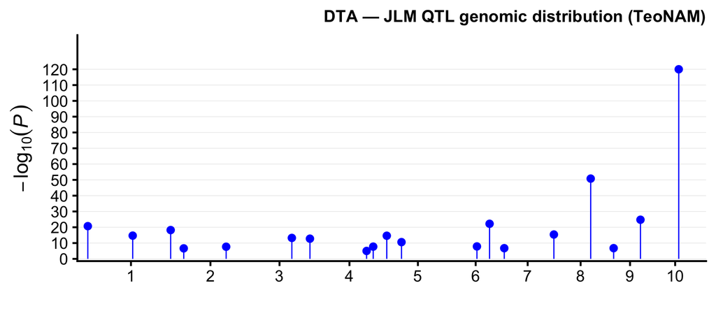

```r
p_lolli <- plot_lollipop(
  here("data/teonam/tassel/dta_jlm_native1.txt"),
  mlm,
  "DTA — JLM QTL genomic distribution (TeoNAM)",
  overlap_csv = here("results/sim/teonam/dta_candidate_overlap.csv"),
  label_genes = c("zcn8", "zcn12", "zmcct9", "zmcct10", "dlf1", "tu1"),
  out_png = here("results/sim/teonam/dta_jlm_lollipop_mlm118k.png")
)
p_lolli
```

## Authentic 118K panel — MLM (Family + K) scan

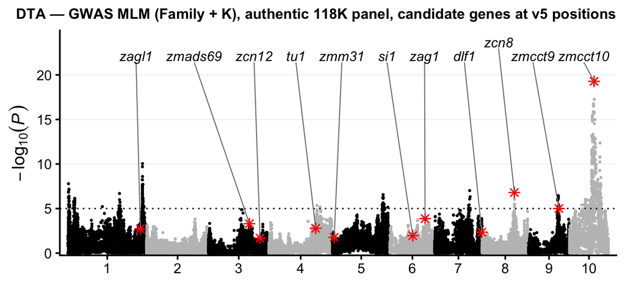

```r
p_mlm <- plot_manhattan(
  mlm,
  "DTA — GWAS MLM (Family + K), authentic 118K panel, candidate genes at v5 positions",
  overlap_csv = here("results/sim/teonam/dta_candidate_overlap.csv"),
  out_png = here("results/sim/teonam/dta_gwas_mlm_manhattan_annotated_118k.png")
)
p_mlm
```

## OLS → MLM on the same panel: the *ZmCCT10*/flowering confound

The fixed-effect OLS scan (`Family + marker`, no K) vs the MLM (`Family + K`) on the identical 118K panel — **same fixed part, K the only addition**. The MLM **deflates λ_GC toward 1** *and* **collapses the flowering peaks**: *ZmCCT10* (chr10) and *ZCN8* (chr8) that dominate OLS are flattened, because teosinte (late-flowering) ancestry there is collinear with K.

```r
ols <- fread(here("data/teonam/dta_gwas_scan_118k.csv"))[is.finite(P) & P > 0, .(SNP, CHR = as.integer(CHR), BP = as.integer(BP), P)]
lam_tab <- data.table(
  model = c("OLS (Family + marker, no K)", "MLM (Family + K)"),
  markers = c(nrow(ols), nrow(mlm)),
  lambda_GC = c(lambda_gc(ols$P), lambda_gc(mlm$P)),
  max_logP = round(c(max(-log10(ols$P)), max(-log10(mlm$P))), 2)
)
knitr::kable(lam_tab, caption = "OLS vs MLM on the authentic 118K panel, same Family fixed part: adding K deflates genomic inflation and the top peak.")
```

OLS vs MLM on the authentic 118K panel, same Family fixed part: adding K deflates genomic inflation and the top peak.

| model | markers | lambda_GC | max_logP |
| --- | --- | --- | --- |
| OLS (Family + marker, no K) | 118514 | 9.029 | 49.36 |
| MLM (Family + K) | 118514 | 2.234 | 19.28 |

```r
ov <- fread(here("results/sim/teonam/dta_candidate_overlap.csv"))
peak_at <- function(scan, ch, s) {
  w <- scan[CHR == ch & abs(BP - s) <= 5e5 & is.finite(P) & P > 0]
  if (!nrow(w)) {
    return(NA_real_)
  }
  round(max(-log10(w$P)), 2)
}
cmp <- ov[, .(
  gene = symbol, chr,
  `OLS peak` = mapply(peak_at, list(ols), chr, start),
  `MLM peak` = mapply(peak_at, list(mlm), chr, start)
)]
cmp[, `drop (OLS−MLM)` := round(`OLS peak` - `MLM peak`, 2)]
setorder(cmp, -`OLS peak`)
knitr::kable(cmp, caption = "Local peak -log10P (+/-500 kb) per candidate: OLS vs MLM. K collapses the flowering peaks (ZmCCT10 the most) — the ancestry-QTL confound.")
```

Local peak -log10P (+/-500 kb) per candidate: OLS vs MLM. K collapses the flowering peaks (ZmCCT10 the most) — the ancestry-QTL confound.

| gene | chr | OLS peak | MLM peak | drop (OLS−MLM) |
| --- | --- | --- | --- | --- |
| zmcct10 | 10 | 49.33 | 19.28 | 30.05 |
| zcn8 | 8 | 23.79 | 6.80 | 16.99 |
| zag1 | 6 | 7.18 | 3.87 | 3.31 |
| zmads69 | 3 | 6.53 | 3.30 | 3.23 |
| zmm31 | 5 | 6.44 | 1.77 | 4.67 |
| zcn12 | 3 | 6.11 | 1.68 | 4.43 |
| tu1 | 4 | 5.74 | 2.78 | 2.96 |
| zmcct9 | 9 | 5.48 | 5.00 | 0.48 |
| si1 | 6 | 4.82 | 1.96 | 2.86 |
| zagl1 | 1 | 4.60 | 2.73 | 1.87 |
| dlf1 | 7 | 3.12 | 2.35 | 0.77 |

## Composite (A: JLM lollipop · B: MLM authentic 118K · C: MLM FSFHap ancestry-imputed)

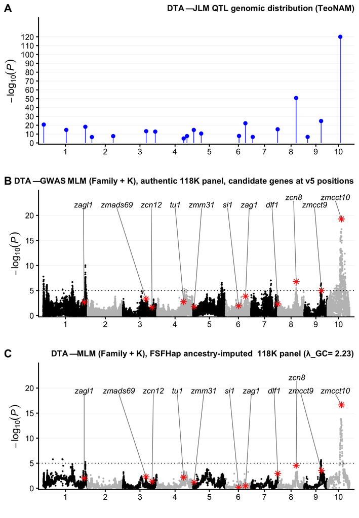

```r
fsf <- fread(here("data/teonam/dta_gwas_mlm_fsfhap_118k.csv"))
lgc_fsf <- lambda_gc(fsf$P)
p_anc <- plot_manhattan(
  fsf,
  sprintf("DTA — MLM (Family + K), FSFHap ancestry-imputed 118K panel (λ_GC = %.2f)", lgc_fsf),
  overlap_csv = here("results/sim/teonam/dta_candidate_overlap.csv"),
  out_png = here("results/sim/teonam/dta_gwas_mlm_fsfhap_manhattan_118k.png")
)
composite <- cowplot::plot_grid(
  p_lolli, p_mlm, p_anc,
  ncol = 1, labels = c("A", "B", "C"), label_size = 20, align = "v", axis = "lr"
)
ggsave(here("results/sim/teonam/dta_composite_mlm_118k.png"), composite, width = 9, height = 13, dpi = 200, bg = "white")
composite
```

## RTIGER ancestry × coverage under MLM (degradation sweep)

The RTIGER coverage sweep under the MLM (Family+K). Reads are Poisson-sampled from the **authentic 118K per-SNP genotypes** over `λ ∈ {0.1, 0.2, 0.5, 1, 5, 10, 20, ∞}×`; RTIGER infers ancestry **directly on all 118K markers, per chromosome** (no thinning, no back-projection), and the per-coverage GL-dosage null (its honest Family+K at that depth) is applied. λ = ∞ is RTIGER’s deterministic ceiling. Compute: `scripts/teonam_rtiger_sweep_118k.R` (writes the OLS and `_mlm` sweep CSVs); this chunk plots.

**Rigidity.** RTIGER’s `rigidity` is a *marker-count* minimum-segment length. The calibrated `rigidity_star = 2` over-segments ~5–6× on this dense grid; a cM-distance rule fails too because the interpolated cM map is heavily tied (median gap ≈ 0). So rigidity is calibrated **empirically on the full grid** — chr1, one family, λ=∞, swept against the FSFHap truth breakpoint density (`agent/rtiger_rigsweep_chr1.R`): **rigidity = 60** reproduces FSFHap’s ~10.4 breakpoints/chr1 (recovered 10.6). That truth-matched segmentation is what makes the profile below smooth rather than the earlier over-segmented sawtooth.

The coverage order is **inverted** relative to OLS: low coverage rides *highest*, ∞ *lowest*. At shallow depth the GL-dosage K is too noisy to correct structure, so the ancestry-confounded QTL leaks through; at ∞ the kinship is well-estimated and crushes it. The chr3 broad 0.1× elevation is a low-coverage MLM artifact (poor K + block recovery in the pericentromere). One replicate per cell.

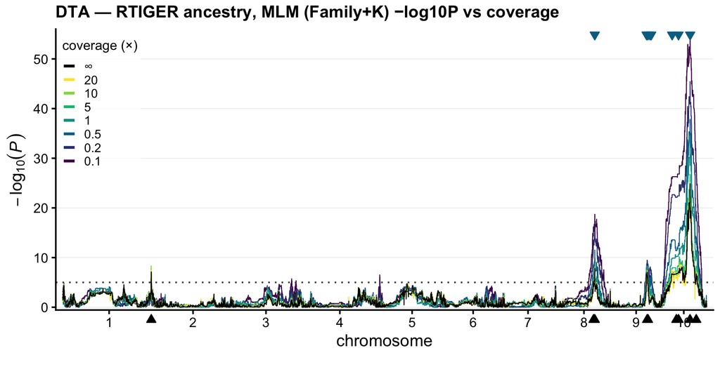

```r
p_sweep <- plot_sweep_line(
  here("results/sim/teonam/dta_gwas_rtiger_118k_mlm_sweep.csv"),
  "DTA — RTIGER ancestry, MLM (Family+K) −log10P vs coverage",
  base_size = 15
)
ggsave(here("results/sim/teonam/dta_gwas_rtiger_118k_mlm_sweep_manhattan.png"), p_sweep, width = 9, height = 4.6, dpi = 200, bg = "white")
p_sweep
```

## MLM coverage-degradation composite: control / nNIL / RTIGER / LB-Impute / binhmm

The dominant *ZmCCT10* (chr10) and *ZCN8* (chr8) flowering QTL survive MLM in **every** caller (only partly confounded with K, and strongest at low coverage), so the panels differentiate mainly on **genome-wide false-positive suppression**, which follows the caller-noisiness ordering below (a property of the recovered ancestry *geometry*):

Read the panels for *false-positive control*, not QTL power (which MLM deliberately removes). One replicate per (family, λ) cell.

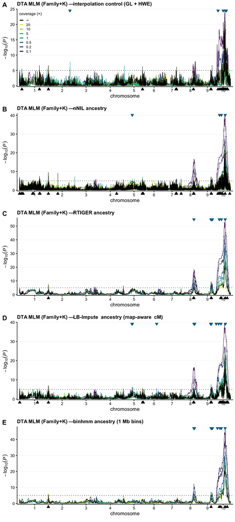

```r
pA <- plot_sweep_line(here("results/sim/teonam/dta_gwas_control_118k_mlm_sweep.csv"), "DTA MLM (Family+K) — interpolation control (GL + HWE)", legend = TRUE)
pB <- plot_sweep_line(here("results/sim/teonam/dta_gwas_nnil_118k_mlm_sweep.csv"), "DTA MLM (Family+K) — nNIL ancestry", legend = FALSE)
pC <- plot_sweep_line(here("results/sim/teonam/dta_gwas_rtiger_118k_mlm_sweep.csv"), "DTA MLM (Family+K) — RTIGER ancestry", legend = FALSE)
pD <- plot_sweep_line(here("results/sim/teonam/dta_gwas_lbimpute_118k_mlm_sweep.csv"), "DTA MLM (Family+K) — LB-Impute ancestry (map-aware cM)", legend = FALSE)
pE <- plot_sweep_line(here("results/sim/teonam/dta_gwas_binhmm_118k_mlm_sweep.csv"), "DTA MLM (Family+K) — binhmm ancestry (1 Mb bins)", legend = FALSE)
composite <- cowplot::plot_grid(pA, pB, pC, pD, pE, ncol = 1, align = "v", axis = "lr", labels = c("A", "B", "C", "D", "E"), label_size = 18)
ggsave(here("results/sim/teonam/dta_sweep_composite_mlm_118k.png"), composite, width = 9, height = 20, dpi = 200, bg = "white")
composite
```